# pandas中的绘图函数 - 1

Series和DataFrame都有一个用于生成各类图表的plot方法。默认情况下，它们所生成的是线形图

## 线形图

简单的Series图表示例,plot()

```python
import numpy as np
import pandas as pd
from pandas import Series,DataFrame

import matplotlib.pyplot as plt
%matplotlib inline
```

```python
plot()
```

```python
线形图反映的是趋势.
```

```python
s = Series(data=np.random.randint(0,10, size=10))
s
```

```
0    4
1    6
2    5
3    8
4    7
5    7
6    5
7    6
8    3
9    0
dtype: int32
```

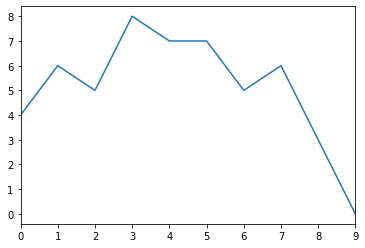

```python
# 以index作为x轴数据, values作为y轴数据
s.plot()
```

简单的DataFrame图表示例,plot()

- 图例的位置可能会随着数据的不同而不同

```python
data = np.random.randint(0,150, size=(4,3))
index = ['张三', '李四', '王五', '赵六']
columns = ['语文', '数学', '英语']
df = DataFrame(index=index, data=data, columns=columns)
df
```

|  | 语文 | 数学 | 英语 |
| --- | --- | --- | --- |
| 张三 | 32 | 72 | 142 |
| 李四 | 15 | 127 | 67 |
| 王五 | 66 | 9 | 99 |
| 赵六 | 29 | 93 | 95 |

[output not shown]

[figure not shown]

```python
df.plot()
```

```python
plt.rcParams['font.sans-serif'] = ['SimHei']
```

[figure not shown]

```python
# 以dataframe的index作为x轴数据, 每一列是一条线
df.plot()
```

```python
df.index = [-1, -2, 0, 1]
df
```

|  | 语文 | 数学 | 英语 |
| --- | --- | --- | --- |
| -1 | 47 | 104 | 39 |
| -2 | 46 | 10 | 130 |
| 0 | 78 | 86 | 27 |
| 1 | 125 | 90 | 140 |

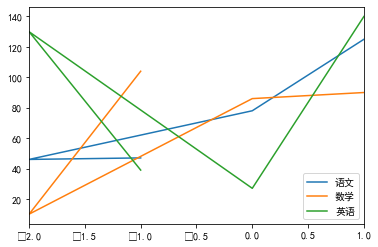

```python
df.plot()
```

```python
# 解决中文字体下负号无法正常显示的问题
plt.rcParams['axes.unicode_minus'] = False
```

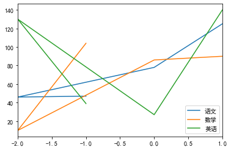

```python
df.plot()
```

## 柱状图

Series柱状图示例,kind = 'bar'/'barh'

```python
柱状图一般用来比较大小
```

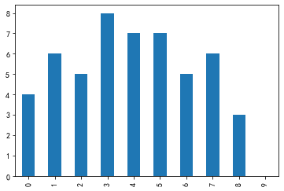

```python
s.plot(kind='bar')
```

DataFrame柱状图示例

[figure not shown]

```python
# 每一行数据放在一起比较大小
df.plot(kind='bar')
```

读取文件tips.csv，查看每天的聚会人数情况 每天各种聚会规模的比例

求和并df.sum()，注意灵活使用axis

```python
tips = pd.read_csv('../data/tips.csv')
tips
```

|  | day | 1 | 2 | 3 | 4 | 5 | 6 |
| --- | --- | --- | --- | --- | --- | --- | --- |
| 0 | Fri | 1 | 16 | 1 | 1 | 0 | 0 |
| 1 | Stat | 2 | 53 | 18 | 13 | 1 | 0 |
| 2 | Sun | 0 | 39 | 15 | 18 | 3 | 1 |
| 3 | Thur | 1 | 48 | 4 | 5 | 1 | 3 |

```python
tips.set_index(keys='day', inplace=True)
```

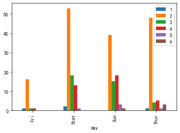

```python
tips.plot(kind='bar')
```

```python
tips.sum(axis=1)
```

```
day
Fri     19
Stat    87
Sun     76
Thur    62
dtype: int64
```

```python
# 先求每一行的和
result = tips.div(tips.sum(axis=1), axis=0)
```

```python
16 / 19
```

```
0.8421052631578947
```

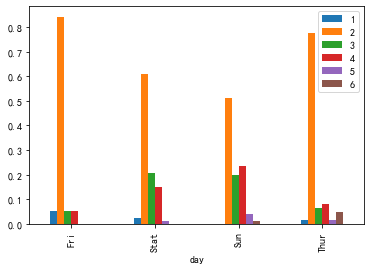

```python
result.plot(kind='bar')
```

## 直方图

```python
直方图一般用来表示数据的分布情况
```

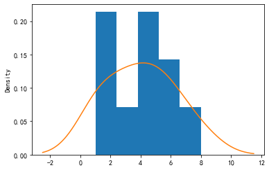

```python
n = np.array([1,1,2,3,4,4,5,6,6,8])
s = Series(data=n)
# 直方图histogram
s.plot(kind='hist', bins=5,  density=True)
# 加入density=True之后,y轴的值变成了概率/组距的结果
# 如果bins设置不太合理,可以加上kde图来显示数据分布
s.plot(kind='kde')
# kde = kernel density estimate
```

```python
!pip install scipy -i https://pypi.douban.com/simple
```

```
  Using cached https://pypi.doubanio.com/packages/9e/fd/9a995b7fc18c6c17ce570b3cfdabffbd2718e4f1830e94777c4fd66e1179/scipy-1.3.0-cp36-cp36m-win_amd64.whl
```

```python
# 计算一组数据的直方数据
np.histogram(n,  bins=100, density=True)
```

```
(array([2.85714286, 0.        , 0.        , 0.        , 0.        ,
        0.        , 0.        , 0.        , 0.        , 0.        ,
        0.        , 0.        , 0.        , 0.        , 1.42857143,
        0.        , 0.        , 0.        , 0.        , 0.        ,
        0.        , 0.        , 0.        , 0.        , 0.        ,
        0.        , 0.        , 0.        , 1.42857143, 0.        ,
        0.        , 0.        , 0.        , 0.        , 0.        ,
        0.        , 0.        , 0.        , 0.        , 0.        ,
        0.        , 0.        , 2.85714286, 0.        , 0.        ,
        0.        , 0.        , 0.        , 0.        , 0.        ,
        0.        , 0.        , 0.        , 0.        , 0.        ,
        0.        , 0.        , 1.42857143, 0.        , 0.        ,
        0.        , 0.        , 0.        , 0.        , 0.        ,
        0.        , 0.        , 0.        , 0.        , 0.        ,
        0.        , 2.85714286, 0.        , 0.        , 0.        ,
        0.        , 0.        , 0.        , 0.        , 0.        ,
        0.        , 0.        , 0.        , 0.        , 0.        ,
        0.        , 0.        , 0.        , 0.        , 0.        ,
        0.        , 0.        , 0.        , 0.        , 0.        ,
        0.        , 0.        , 0.        , 0.        , 1.42857143]),
 array([1.  , 1.07, 1.14, 1.21, 1.28, 1.35, 1.42, 1.49, 1.56, 1.63, 1.7 ,
        1.77, 1.84, 1.91, 1.98, 2.05, 2.12, 2.19, 2.26, 2.33, 2.4 , 2.47,
        2.54, 2.61, 2.68, 2.75, 2.82, 2.89, 2.96, 3.03, 3.1 , 3.17, 3.24,
        3.31, 3.38, 3.45, 3.52, 3.59, 3.66, 3.73, 3.8 , 3.87, 3.94, 4.01,
        4.08, 4.15, 4.22, 4.29, 4.36, 4.43, 4.5 , 4.57, 4.64, 4.71, 4.78,
        4.85, 4.92, 4.99, 5.06, 5.13, 5.2 , 5.27, 5.34, 5.41, 5.48, 5.55,
        5.62, 5.69, 5.76, 5.83, 5.9 , 5.97, 6.04, 6.11, 6.18, 6.25, 6.32,
        6.39, 6.46, 6.53, 6.6 , 6.67, 6.74, 6.81, 6.88, 6.95, 7.02, 7.09,
        7.16, 7.23, 7.3 , 7.37, 7.44, 7.51, 7.58, 7.65, 7.72, 7.79, 7.86,
        7.93, 8.  ]))
```

```python
0.2 / 0.07
```

```
2.857142857142857
```

rondom生成随机数百分比直方图，调用hist方法

- 柱高表示数据的频数，柱宽表示各组数据的组距
- 参数bins可以设置直方图方柱的个数上限，越大柱宽越小，数据分组越细致
- 设置density参数为True，可以把频数转换为概率

kde图：核密度估计，用于弥补直方图由于参数bins设置的不合理导致的精度缺失问题

#### 练习

绘制一个由两个不同的正态分布组成的的双峰分布

```python
n1 = np.random.normal(loc=5, scale=5, size=10000)
n2 = np.random.normal(loc=30, scale=8, size=10000)

n = np.hstack((n1,n2))
```

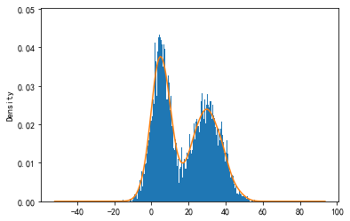

```python
s = Series(data=n)
s.plot(kind='hist', bins=500, density=True)
s.plot(kind='kde')
```

## 散布图(散点图)

散布图 散布图是观察两个一维数据数列之间的关系的有效方法,DataFrame对象可用

使用方法： 设置kind = 'scatter'，给明标签columns

```python
散点图研究两个一维数据之间的关系.
```

```python
df = DataFrame({'A': np.random.randn(1000), 'B': np.random.randn(1000), 'C': np.random.randn(1000), 'D': np.random.randn(1000)})
df.head()
```

|  | A | B | C | D |
| --- | --- | --- | --- | --- |
| 0 | 1.350469 | -0.757953 | -0.130467 | -0.558658 |
| 1 | 1.703911 | -0.053533 | -1.290569 | 0.619652 |
| 2 | -0.132011 | 1.871678 | -0.383147 | -0.774807 |
| 3 | -0.632711 | 1.487892 | 0.447683 | -2.492515 |
| 4 | 0.937552 | -0.200019 | -0.449218 | -0.776772 |

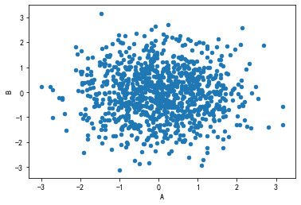

```python
df.plot(x='A', y='B', kind='scatter')
```

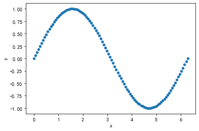

```python
x = np.linspace(0, 2*np.pi, 100)
y = np.sin(x)
df2 = DataFrame({'x': x, 'y':y})
df2.plot(x='x', y='y', kind='scatter')
```

散布图矩阵，当有多个点时，两两点的关系

使用函数：pd.plotting.scatter_matrix(),

- 参数diagnol：设置对角线的图像类型

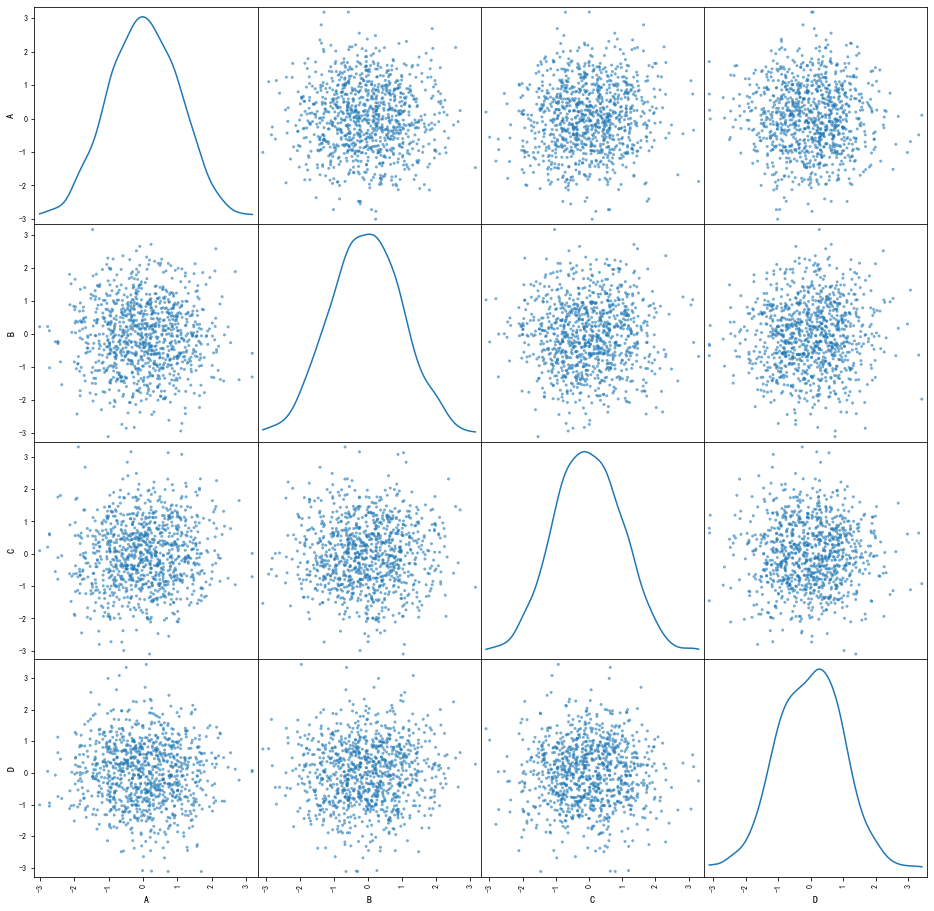

```python
_ = pd.plotting.scatter_matrix(df, figsize=(16,  16), alpha=0.6, diagonal='kde')
```